# seminar_2_solution

## Seminar 2 Solutions

The key concept in this exercise is the discount rate. A typical discount rate less than 1 implies that future benefits and costs are de-prioritised in favour of more recent ones. Different people may subconsciously apply different discount rates, depending on how forward-thinking they are. Why discount the future?

- Money spent today on a project expected to produce benefits in the future could instead be invested (e.g. in the stock market) and yield interest revenue in the meantime.
- Future costs and benefits and costs are uncertain. You may not be alive to see them!

The "net present value" is the sum of all discounted benefits minus the sum of all discounted costs. It's how we determine whether it's worth our investment to start a project which will take a long time.

[figure not shown]

What does this imply for how we think about stock pollutants and climate change?

### Problem

The World Bank is considering an application from the country of Equatoria for a large dam project. Some costs and benefits of the project (dollar values) are as follow:

- Construction costs: $500M/year for three years.
- Operating costs: $50M/year
- Hydropower to be generated: 3 bill. Kilowatt hours/year
- Price of electricity: $0.05/Kilowatt hour
- Irrigation water available from the dam: 5B gallons/year
- Price of water: $0.02/gallon
- Agricultural product lost from flooded lands: $45M/year
- Forest products lost from flooded lads: $20M/year

```r
# costs
construction_cost <- 5e+8 # for three years
operation_cost    <- 5e+7 # per year
agri_damage       <- 4.5e+7 # per year
forest_damage     <- 2e+7 #per year

# production
water_supply <- 5e+9
power_supply <- 3e+9
# prices
water_price  <- 0.02
power_price  <- 0.05
```

### The net present value equation:

The dam takes three years to construct, during this period there are only initial costs but no revenue.

Present value of costs:

### $PC = \sum_{t = 0}^{T = 2}\frac{1}{(1 + r)^{t}}(Q_{construction}) + \sum_{t = 3}^{T = 32}\frac{1}{(1 + r)^{t}} (C_{operation} + D) \label{eq1}$

Present value of benefits:

### $PB = \sum_{t = 3}^{T = 32} \frac{1}{(1 + r)^{t}} (P_{power} * Q_{power} + P_{water} * Q_{water}) \label{eq2}$

```r
PV_BENEFITS <- matrix(nrow = 33, ncol = 2)
PV_COSTS <- matrix(nrow = 33, ncol = 2)

# we want to calculate NPV using two different discount rates of 5% and 10%
discount_rate <- c(0.05, 0.1)

for ( i in 1:length(discount_rate)) {

  for ( t in 1:33) {

    if ( t > 3) {

    PV_BENEFITS[t, i] <- (power_price*power_supply + water_price*water_supply)*(1/(1 + discount_rate[i])^(t-1))
    PV_COSTS[t, i] <- (operation_cost + agri_damage + forest_damage)*(1/(1 + discount_rate[i])^(t-1))

    }

    else { PV_BENEFITS[t, i] <- 0
         PV_COSTS[t, i] <- construction_cost*(1/(1 + discount_rate[i])^(t-1)) }
  }
}

#
pv <- PV_BENEFITS - PV_COSTS
pv_total <- colSums(PV_BENEFITS) - colSums(PV_COSTS)
pv_data <- data.frame('PV' = c(pv[,1], pv[,2]), 'YEAR' = 0:32, 'RATE' = c(rep('5%', 33),rep('10%', 33)))

head(pv_data)
```

A data.frame: 6 × 3

|  | PV <dbl> | YEAR <int> | RATE <chr> |
| --- | --- | --- | --- |
| 1 | -500000000 | 0 | 5% |
| 2 | -476190476 | 1 | 5% |
| 3 | -453514739 | 2 | 5% |
| 4 | 116618076 | 3 | 5% |
| 5 | 111064834 | 4 | 5% |
| 6 | 105776032 | 5 | 5% |

```r
tail(pv_data[28:33,])
```

A data.frame: 6 × 3

|  | PV <dbl> | YEAR <int> | RATE <chr> |
| --- | --- | --- | --- |
| 28 | 36159523 | 27 | 5% |
| 29 | 34437641 | 28 | 5% |
| 30 | 32797753 | 29 | 5% |
| 31 | 31235956 | 30 | 5% |
| 32 | 29748529 | 31 | 5% |
| 33 | 28331932 | 32 | 5% |

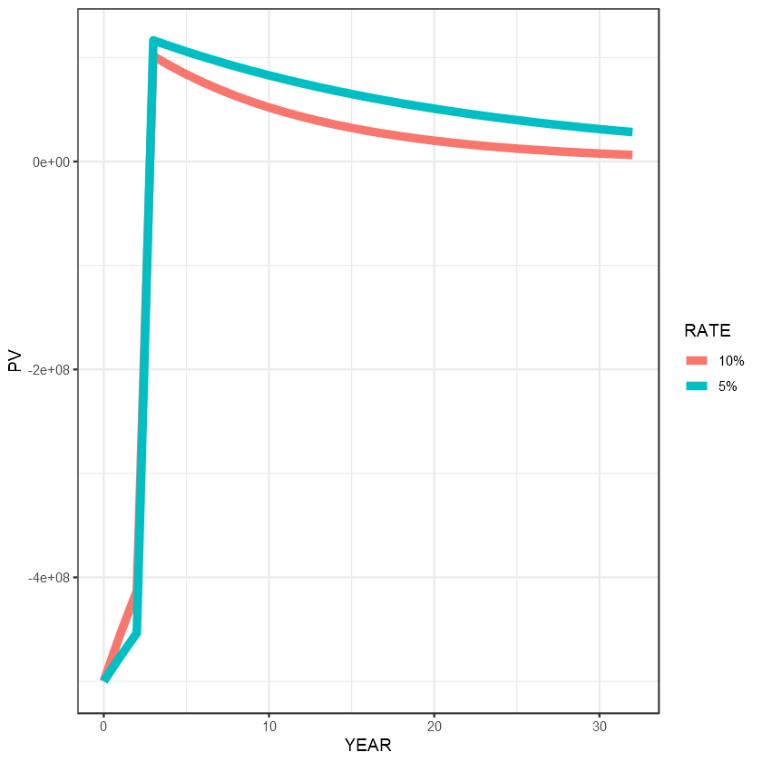

```r
library(ggplot2)
library(dplyr)

ggplot(data = pv_data, aes(x = YEAR, y = PV, colour = RATE)) + geom_line(size = 2) + theme_bw()
```

```r
pv_data %>% group_by(RATE) %>% summarize(NPV = sum(PV))
```

A tibble: 2 × 2

| RATE <chr> | NPV <dbl> |
| --- | --- |
| 10% | -316005411 |
| 5% | 452635727 |